# data_exploration

Ben Jefferies

2025-10-24

## Library

```r
library(tidyverse)
library(xray)
library(readr)
library(readxl)
library(here)
library(janitor)
library(gtsummary)
library(margins)
library(pander)
```

# Summary

current public views of higher ed along with a shrinking population of potential first year traditional college students requires us to think creatively about methods to increase and stabilize enrollment at NAU.

Strat goal: broaden access to create a student population that reflects the state, complements out-of-state and international enrollment. Increase statewide/online enrollment. Improve retention rates.

Strat goal: support enrollment and retention for Indigenous students.

## Data

Cleaning:

1. There was one initial error in the dataset in the ‘Accept Date’ column. The column was incorrectly formatted as numeric and needed to be adjusted by adding to the Excel Origin 1899-12-30.
2. In offered_aid_amount, NA’s need to be converted to $0

```r
#find local files
local_files <- list.files(path = here())

# restrict list of local files to those ending in .xlsx
local_files <- local_files[grepl(pattern = ".xlsx$", x = local_files)]

# read in to dat
dat <- readxl::read_xlsx(here(local_files))

dat <- janitor::clean_names(dat)
```

```r
# clean accept_date column, numeric values are days added to the Excel origin
dat <- dat %>%
  mutate(accept_date = as.Date(accept_date, origin = "1899-12-30"))

# convert all NA's in offered aid to $0
dat <- dat %>%
  mutate(offered_aid_amount = round( ifelse(is.na(offered_aid_amount), 0, offered_aid_amount), 0))

# convert ethnicity, household income field to factor
dat <- dat %>%
  mutate(ipeds_ethnicity = factor(ipeds_ethnicity),
         household_income = factor(household_income,
                                   levels = c(">= $150,000", "$125,000 - $149,999", ">= $120,000", "$100,000 - $124,999", "$80,000 - $119,999", "$75,000 - $99,999", "$65,000 - $79,999", "$50,000 - $74,999", "$50,000 - $64,999", "$35,000 - $49,999", "$25,000 - $49,999", "$20,000 - $34,999", "< $25,000", "< $20,000", NA)))

# create dummy variable for received aid
dat <- dat %>%
  mutate(aid_offered = ifelse(offered_aid_amount > 0, 1, 0))
```

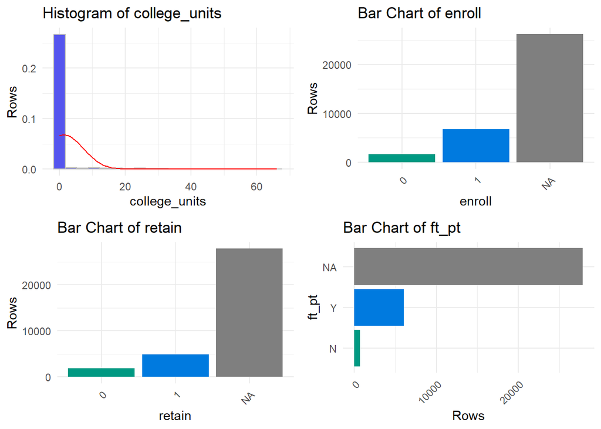

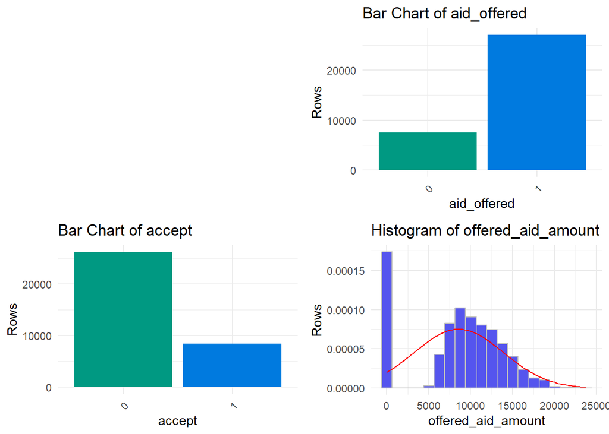

```
## [1] "Ignoring variable accept_date: Unsupported type for visualization."
```

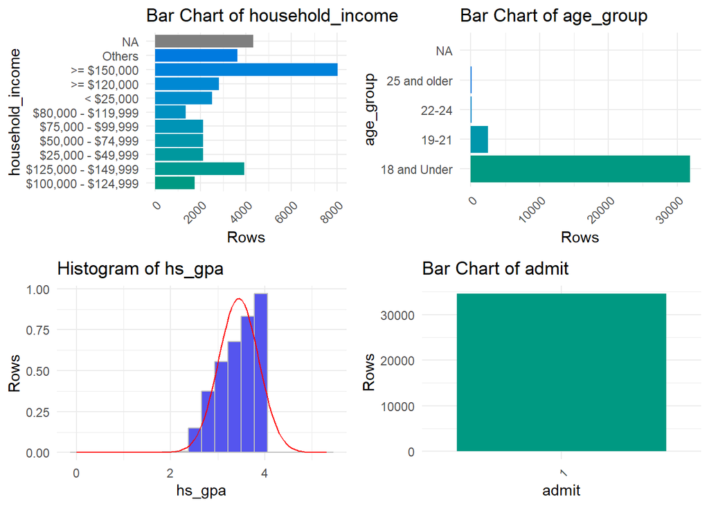

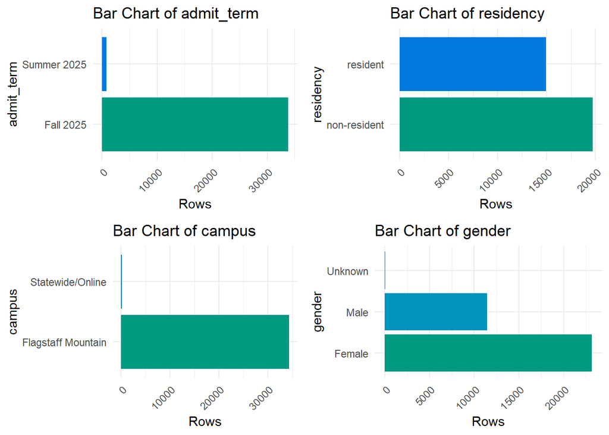

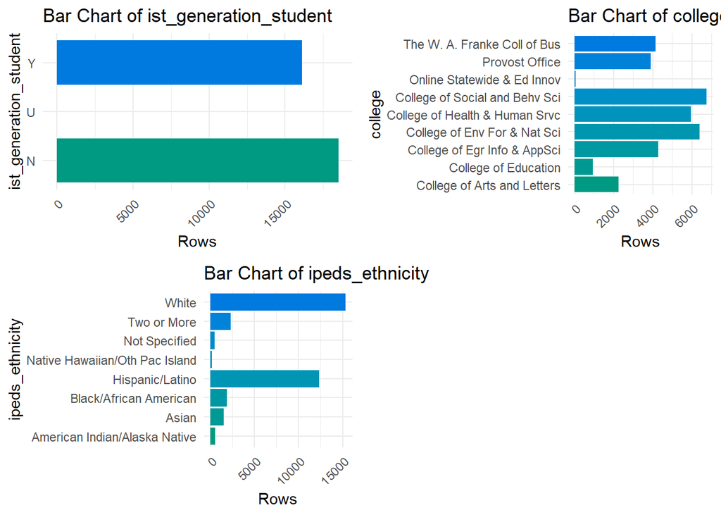

```
## [1] "Ignoring variable admit_date: Unsupported type for visualization."
```

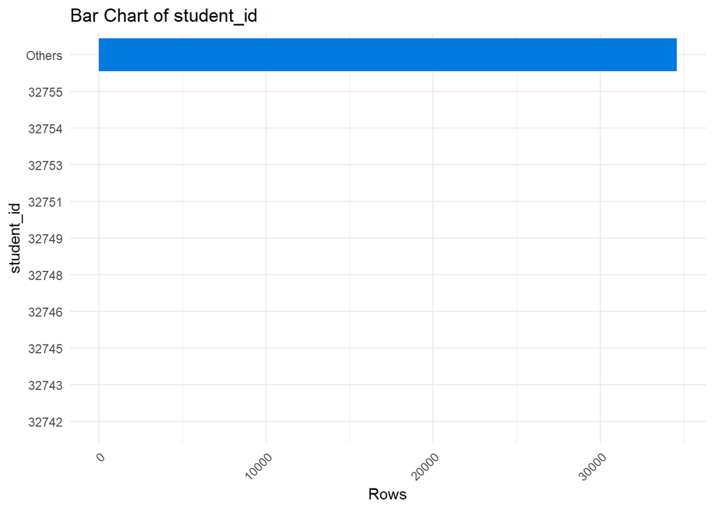

```
##             Variable  p_1 p_10 p_25 p_50  p_75  p_90  p_99
## 1      college_units    0    0    0    0     0     0    32
## 2             retain    0    0    0    1     1     1     1
## 3             enroll    0    0    1    1     1     1     1
## 4             accept    0    0    0    0     0     1     1
## 5        aid_offered    0    0    1    1     1     1     1
## 6 offered_aid_amount    0    0 6405 9349 12295 14690 19094
## 7             hs_gpa 2.49 2.83 3.13 3.51  3.81  3.97     4
## 8              admit    1    1    1    1     1     1     1
```

```r
xray::distributions(dat)
```

## KPI Descriptive Stats

Overall apply - admit - accept - retain funnel

Summary: of those admitted, 1/4 accept and of those 80% enrolled in the following Fall. Of those who enrolled, 73% were retained after their first year.

TO DO:

1. pull IPEDS national data for past year on average retention rates for comparable southwestern publics of similar size.
2. pull statistics on Arizona population distribution (to test for effective representation) https://datausa.io/profile/geo/arizona#demographics
3. Create this funnel chart in powerbi

```r
dat %>%
  summarise(total_admit = sum(admit, na.rm = T),
            total_accept = sum(accept, na.rm = T),
            total_enroll = sum(enroll, na.rm = T),
            total_retain = sum(retain, na.rm = T))
```

```
## # A tibble: 1 × 4
##   total_admit total_accept total_enroll total_retain
##         <dbl>        <dbl>        <dbl>        <dbl>
## 1       34628         8379         6761         4910
```

Split by Gender, we can see twice as many women applied as men.

```r
dat %>%
  group_by(gender) %>%
  summarise(total_admit = sum(admit, na.rm = T),
            total_accept = sum(accept, na.rm = T),
            pct_accept = round( sum(accept, na.rm = T) / sum(admit, na.rm = T), 2),
            total_enroll = sum(enroll, na.rm = T),
            pct_enroll = round( sum(enroll, na.rm = T) / sum(accept, na.rm = T), 2),
            total_retain = sum(retain, na.rm = T),
            pct_retain = round( sum(retain, na.rm = T) / sum(enroll, na.rm = T), 2))
```

```
## # A tibble: 3 × 8
##   gender  total_admit total_accept pct_accept total_enroll pct_enroll
##   <chr>         <dbl>        <dbl>      <dbl>        <dbl>      <dbl>
## 1 Female        23171         5373       0.23         4326       0.81
## 2 Male          11438         3005       0.26         2434       0.81
## 3 Unknown          19            1       0.05            1       1
## # ℹ 2 more variables: total_retain <dbl>, pct_retain <dbl>
```

Split by Ethnicity

```r
dat %>%
  group_by(ipeds_ethnicity) %>%
  summarise(total_admit = sum(admit, na.rm = T),
            total_accept = sum(accept, na.rm = T),
            pct_accept = round( sum(accept, na.rm = T) / sum(admit, na.rm = T), 2),
            total_enroll = sum(enroll, na.rm = T),
            pct_enroll = round( sum(enroll, na.rm = T) / sum(accept, na.rm = T), 2),
            total_retain = sum(retain, na.rm = T),
            pct_retain = round( sum(retain, na.rm = T) / sum(enroll, na.rm = T), 2))
```

```
## # A tibble: 8 × 8
##   ipeds_ethnicity    total_admit total_accept pct_accept total_enroll pct_enroll
##   <fct>                    <dbl>        <dbl>      <dbl>        <dbl>      <dbl>
## 1 American Indian/A…         554          198       0.36          155       0.78
## 2 Asian                     1521          178       0.12          146       0.82
## 3 Black/African Ame…        1858          343       0.18          244       0.71
## 4 Hispanic/Latino          12372         2304       0.19         1718       0.75
## 5 Native Hawaiian/O…         192           34       0.18           24       0.71
## 6 Not Specified              475           84       0.18           69       0.82
## 7 Two or More               2304          567       0.25          460       0.81
## 8 White                    15352         4671       0.3          3945       0.84
## # ℹ 2 more variables: total_retain <dbl>, pct_retain <dbl>
```

Split by First Gen

```r
dat %>%
  group_by(ist_generation_student) %>%
  summarise(total_admit = sum(admit, na.rm = T),
            total_accept = sum(accept, na.rm = T),
            pct_accept = round( sum(accept, na.rm = T) / sum(admit, na.rm = T), 2),
            total_enroll = sum(enroll, na.rm = T),
            pct_enroll = round( sum(enroll, na.rm = T) / sum(accept, na.rm = T), 2),
            total_retain = sum(retain, na.rm = T),
            pct_retain = round( sum(retain, na.rm = T) / sum(enroll, na.rm = T), 2))
```

```
## # A tibble: 3 × 8
##   ist_generation_student total_admit total_accept pct_accept total_enroll
##   <chr>                        <dbl>        <dbl>      <dbl>        <dbl>
## 1 N                            18495         4851       0.26         4090
## 2 U                               11            9       0.82            8
## 3 Y                            16122         3519       0.22         2663
## # ℹ 3 more variables: pct_enroll <dbl>, total_retain <dbl>, pct_retain <dbl>
```

### Ethnic breakdown of cohort

Question: Does the cohort in this dataset have an ethnic distribution matching AZ state? are the students in this recruitment cycle demographically representative of the State of AZ?

Results: This cohort has an over-representation of white students and Indigenous and Hispanic students are under-represented.

Visualize: line chart comparing white, hispanic and indigenous with percentages of student body. x-axis is (admit, accept, enroll, retain) y axis is percentage of cohort

Investigate: what factors are correlated with increasing the probability of accept, enroll, retain for each ethnic group.

```r
dat %>%
  group_by(ipeds_ethnicity) %>%
  summarize(admit = sum(admit, na.rm = T),
            accept = sum(accept, na.rm = T)) %>%
  mutate(pct_admit = round( admit / sum(admit), 4),
         pct_accept = round( accept / sum(accept), 4)) %>%
  select(ipeds_ethnicity, admit, pct_admit, accept, pct_accept)
```

```
## # A tibble: 8 × 5
##   ipeds_ethnicity                admit pct_admit accept pct_accept
##   <fct>                          <dbl>     <dbl>  <dbl>      <dbl>
## 1 American Indian/Alaska Native    554    0.016     198     0.0236
## 2 Asian                           1521    0.0439    178     0.0212
## 3 Black/African American          1858    0.0537    343     0.0409
## 4 Hispanic/Latino                12372    0.357    2304     0.275
## 5 Native Hawaiian/Oth Pac Island   192    0.0055     34     0.0041
## 6 Not Specified                    475    0.0137     84     0.01
## 7 Two or More                     2304    0.0665    567     0.0677
## 8 White                          15352    0.443    4671     0.558
```

```r
dat %>%
  group_by(ipeds_ethnicity) %>%
  summarize(enroll = sum(enroll, na.rm = T),
            retain = sum(retain, na.rm = T)) %>%
  mutate(pct_enroll = round( enroll / sum(enroll), 4),
         pct_retain = round( retain / sum(retain), 4)) %>%
  select(ipeds_ethnicity, enroll, pct_enroll, retain, pct_retain)
```

```
## # A tibble: 8 × 5
##   ipeds_ethnicity                enroll pct_enroll retain pct_retain
##   <fct>                           <dbl>      <dbl>  <dbl>      <dbl>
## 1 American Indian/Alaska Native     155     0.0229     97     0.0198
## 2 Asian                             146     0.0216    119     0.0242
## 3 Black/African American            244     0.0361    138     0.0281
## 4 Hispanic/Latino                  1718     0.254    1164     0.237
## 5 Native Hawaiian/Oth Pac Island     24     0.0035     14     0.0029
## 6 Not Specified                      69     0.0102     45     0.0092
## 7 Two or More                       460     0.068     335     0.0682
## 8 White                            3945     0.584    2998     0.611
```

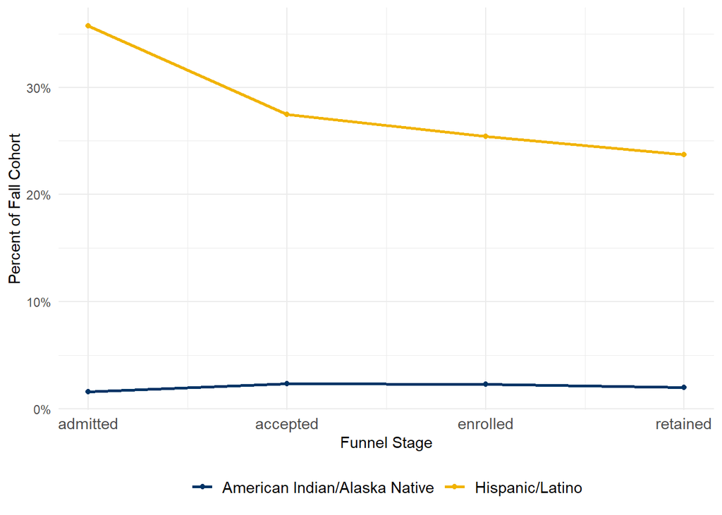

```r
# create data frame for visualization rates over time
funnel_ipeds <- dat %>%
  group_by(ipeds_ethnicity) %>%
  summarize(admit = sum(admit, na.rm = T),
            accept = sum(accept, na.rm = T),
            enroll = sum(enroll, na.rm = T),
            retain = sum(retain, na.rm = T)) %>%
  mutate(pct_admit = round( admit / sum(admit), 4),
         pct_accept = round( accept / sum(accept), 4),
         pct_enroll = round( enroll / sum(enroll), 4),
         pct_retain = round( retain / sum(retain), 4))


# pivot summary data by ethnicity longer
funnel_ipeds_long <- funnel_ipeds %>%
  pivot_longer(cols = c(admit, accept, enroll, retain),
                names_to = "funnel_stage",
               values_to = "total")

# finish pivot, assigning percent to each row
funnel_ipeds_long <- funnel_ipeds_long %>%
  mutate(pct = case_when(funnel_stage == "admit" ~ pct_admit,
                         funnel_stage == "accept" ~ pct_accept,
                         funnel_stage == "enroll" ~ pct_enroll,
                         funnel_stage == "retain" ~ pct_retain)) %>%
  select(ipeds_ethnicity, funnel_stage, total, pct)


funnel_ipeds_long$funnel_stage <- factor(funnel_ipeds_long$funnel_stage,
                                         levels = c("admit", "accept", "enroll", "retain"))

funnel_ipeds_long <- funnel_ipeds_long %>%
  mutate(index = case_when(funnel_stage == "admit" ~ 1,
                           funnel_stage == "accept" ~ 2,
                           funnel_stage == "enroll" ~ 3,
                           funnel_stage == "retain" ~ 4,))

nau_colors <- c("#003466", "#F1B300", "#00853F", "#F47722", "#00ADB5", "#E86D1F")

funnel_ipeds_long %>%
  filter(ipeds_ethnicity %in% c("American Indian/Alaska Native",
                                "Hispanic/Latino")) %>%
  ggplot(aes(x = index, y = pct, colour = ipeds_ethnicity)) +
  geom_point() +
  geom_path(lwd = 1) +
  scale_y_continuous(labels = scales::percent) +
  scale_x_continuous(labels = c("admitted", "accepted", "enrolled", "retained")) +
  scale_color_manual(values = nau_colors) +
  labs(y = "Percent of Fall Cohort",
       x = "Funnel Stage") +
  theme_minimal() +
  theme(legend.title = element_blank(),
        legend.position = "bottom",
        legend.text = element_text(size = 11),
        axis.text.x = element_text(size = 11))
```

#### Hispanic/Native Male/Female

```r
dat %>%
  filter(ipeds_ethnicity %in% c("Hispanic/Latino", "American Indian/Alaska Native")) %>%
  group_by(ipeds_ethnicity, gender) %>%
  summarise(pct_accept = sum(accept, na.rm = T) / sum(admit, na.rm = T),
            pct_enroll = sum(enroll, na.rm = T) / sum(accept, na.rm = T),
            pct_retain = sum(retain, na.rm = T) / sum(enroll, na.rm = T)) %>%
  pander()
```

| ipeds_ethnicity | gender | pct_accept | pct_enroll | pct_retain |
| --- | --- | --- | --- | --- |
| American Indian/Alaska Native | Female | 0.3398 | 0.7929 | 0.6126 |
| American Indian/Alaska Native | Male | 0.4085 | 0.7586 | 0.6591 |
| Hispanic/Latino | Female | 0.1808 | 0.7487 | 0.6839 |
| Hispanic/Latino | Male | 0.1993 | 0.7391 | 0.6636 |
| Hispanic/Latino | Unknown | 0 | NA | NA |

### Family Income

Question: Who are those students, resident or non?

```r
# summarize enroll and retain rates by household income band
dat %>%
  group_by(household_income) %>%
  summarize(enroll = sum(enroll, na.rm = T),
            retain = sum(retain, na.rm = T)) %>%
  mutate(pct_enroll = round( enroll / sum(enroll), 4),
         pct_retain = round( retain / sum(retain), 4)) %>%
  select(household_income, enroll, pct_enroll, retain, pct_retain)
```

```
## # A tibble: 15 × 5
##    household_income    enroll pct_enroll retain pct_retain
##    <fct>                <dbl>      <dbl>  <dbl>      <dbl>
##  1 >= $150,000           1788     0.264    1395     0.284
##  2 $125,000 - $149,999    884     0.131     652     0.133
##  3 >= $120,000            640     0.0947    496     0.101
##  4 $100,000 - $124,999    351     0.0519    254     0.0517
##  5 $80,000 - $119,999     310     0.0459    222     0.0452
##  6 $75,000 - $99,999      389     0.0575    281     0.0572
##  7 $65,000 - $79,999      113     0.0167     90     0.0183
##  8 $50,000 - $74,999      420     0.0621    275     0.056
##  9 $50,000 - $64,999      117     0.0173     80     0.0163
## 10 $35,000 - $49,999      136     0.0201     85     0.0173
## 11 $25,000 - $49,999      429     0.0635    283     0.0576
## 12 $20,000 - $34,999      141     0.0209     97     0.0198
## 13 < $25,000              566     0.0837    376     0.0766
## 14 < $20,000              190     0.0281    127     0.0259
## 15 <NA>                   287     0.0424    197     0.0401
```

```r
#
dat %>%
  group_by(residency, household_income) %>%
  summarize(enroll = sum(enroll, na.rm = T),
            retain = sum(retain, na.rm = T)) %>%
  mutate(pct_enroll = round( enroll / sum(enroll), 4),
         pct_retain = round( retain / sum(retain), 4)) %>%
  select(household_income, enroll, pct_enroll, retain, pct_retain)
```

```
## # A tibble: 30 × 6
## # Groups:   residency [2]
##    residency    household_income    enroll pct_enroll retain pct_retain
##    <chr>        <fct>                <dbl>      <dbl>  <dbl>      <dbl>
##  1 non-resident >= $150,000            728     0.325     567     0.360
##  2 non-resident $125,000 - $149,999    261     0.116     177     0.112
##  3 non-resident >= $120,000            269     0.120     209     0.133
##  4 non-resident $100,000 - $124,999     99     0.0441     66     0.042
##  5 non-resident $80,000 - $119,999      83     0.037      56     0.0356
##  6 non-resident $75,000 - $99,999      101     0.045      67     0.0426
##  7 non-resident $65,000 - $79,999       26     0.0116     21     0.0134
##  8 non-resident $50,000 - $74,999      110     0.049      71     0.0451
##  9 non-resident $50,000 - $64,999       31     0.0138     18     0.0114
## 10 non-resident $35,000 - $49,999       40     0.0178     23     0.0146
## # ℹ 20 more rows
```

### Modelling Acceptance Logistic

Methodology: logistic regression

Results: highly statistically significant result that shows additional $1000 in offered aid increases the likelihood of a student accepting their offer by 4%. So a student with a $10000 aid package is 40% more likely to accept their offer than a comparable student with no offered aid. This result applies regardless of ethnicity, there was no statistically significant difference in the effect of financial aid offers between ethnic groups.

```r
# explore contributing factors to acceptance with logistic regression
m_log_accept <- glm(accept ~ offered_aid_amount,
                    data = dat,
                    family = binomial)

summary(m_log_accept)
```

```
##
## Call:
## glm(formula = accept ~ offered_aid_amount, family = binomial,
##     data = dat)
##
## Coefficients:
##                      Estimate Std. Error z value Pr(>|z|)
## (Intercept)        -1.483e+00  2.558e-02  -57.98   <2e-16 ***
## offered_aid_amount  3.856e-05  2.437e-06   15.82   <2e-16 ***
## ---
## Signif. codes:  0 '***' 0.001 '**' 0.01 '*' 0.05 '.' 0.1 ' ' 1
##
## (Dispersion parameter for binomial family taken to be 1)
##
##     Null deviance: 38322  on 34627  degrees of freedom
## Residual deviance: 38066  on 34626  degrees of freedom
## AIC: 38070
##
## Number of Fisher Scoring iterations: 4
```

```r
me_m_log_accept <- margins::margins(m_log_accept)

summary(me_m_log_accept)
```

```
##              factor    AME     SE       z      p  lower  upper
##  offered_aid_amount 0.0000 0.0000 15.9608 0.0000 0.0000 0.0000
```

```r
# convert log-odds to odds-ratio
oddsRatio <- exp(m_log_accept$coefficients[2])

# convert odds ratio to units per $1000 of financial aid
oddsRatio <- oddsRatio^1000
```

In the logit model with interaction terms below, we see results are statistically the same for all ethnic groups, no statistically significant difference exists.

```r
# logistic regression model controlling for ethnicity
m_log_accept_controls <- glm(accept ~ offered_aid_amount * ipeds_ethnicity,
                    data = dat,
                    family = binomial)

summary(m_log_accept_controls)
```

```
##
## Call:
## glm(formula = accept ~ offered_aid_amount * ipeds_ethnicity,
##     family = binomial, data = dat)
##
## Coefficients:
##                                                                    Estimate
## (Intercept)                                                      -1.096e+00
## offered_aid_amount                                                5.119e-05
## ipeds_ethnicityAsian                                             -1.273e+00
## ipeds_ethnicityBlack/African American                            -8.364e-01
## ipeds_ethnicityHispanic/Latino                                   -8.203e-01
## ipeds_ethnicityNative Hawaiian/Oth Pac Island                    -3.904e-01
## ipeds_ethnicityNot Specified                                     -5.090e-01
## ipeds_ethnicityTwo or More                                       -6.106e-01
## ipeds_ethnicityWhite                                             -2.372e-01
## offered_aid_amount:ipeds_ethnicityAsian                          -7.243e-06
## offered_aid_amount:ipeds_ethnicityBlack/African American         -4.919e-06
## offered_aid_amount:ipeds_ethnicityHispanic/Latino                -8.278e-06
## offered_aid_amount:ipeds_ethnicityNative Hawaiian/Oth Pac Island -5.843e-05
## offered_aid_amount:ipeds_ethnicityNot Specified                  -4.231e-05
## offered_aid_amount:ipeds_ethnicityTwo or More                     1.740e-05
## offered_aid_amount:ipeds_ethnicityWhite                           1.236e-05
##                                                                  Std. Error
## (Intercept)                                                       1.807e-01
## offered_aid_amount                                                1.534e-05
## ipeds_ethnicityAsian                                              2.346e-01
## ipeds_ethnicityBlack/African American                             2.167e-01
## ipeds_ethnicityHispanic/Latino                                    1.878e-01
## ipeds_ethnicityNative Hawaiian/Oth Pac Island                     3.499e-01
## ipeds_ethnicityNot Specified                                      2.733e-01
## ipeds_ethnicityTwo or More                                        2.106e-01
## ipeds_ethnicityWhite                                              1.846e-01
## offered_aid_amount:ipeds_ethnicityAsian                           2.151e-05
## offered_aid_amount:ipeds_ethnicityBlack/African American          1.839e-05
## offered_aid_amount:ipeds_ethnicityHispanic/Latino                 1.591e-05
## offered_aid_amount:ipeds_ethnicityNative Hawaiian/Oth Pac Island  3.725e-05
## offered_aid_amount:ipeds_ethnicityNot Specified                   2.670e-05
## offered_aid_amount:ipeds_ethnicityTwo or More                     1.874e-05
## offered_aid_amount:ipeds_ethnicityWhite                           1.588e-05
```

[output cut: 29 more lines]

```
## offered_aid_amount:ipeds_ethnicityHispanic/Latino                0.602932
## offered_aid_amount:ipeds_ethnicityNative Hawaiian/Oth Pac Island 0.116730
## offered_aid_amount:ipeds_ethnicityNot Specified                  0.113044
## offered_aid_amount:ipeds_ethnicityTwo or More                    0.353225
## offered_aid_amount:ipeds_ethnicityWhite                          0.436388
## ---
## Signif. codes:  0 '***' 0.001 '**' 0.01 '*' 0.05 '.' 0.1 ' ' 1
##
## (Dispersion parameter for binomial family taken to be 1)
##
##     Null deviance: 38322  on 34627  degrees of freedom
## Residual deviance: 37108  on 34612  degrees of freedom
## AIC: 37140
##
## Number of Fisher Scoring iterations: 4
```

```r
# marginal effects for accept/control model
me_m_log_accept_c <- margins::margins(m_log_accept_controls)

summary(me_m_log_accept_c)
```

```
##                                         factor     AME     SE        z      p
##                           ipeds_ethnicityAsian -0.2219 0.0221 -10.0426 0.0000
##          ipeds_ethnicityBlack/African American -0.1641 0.0222  -7.4057 0.0000
##                 ipeds_ethnicityHispanic/Latino -0.1664 0.0206  -8.0765 0.0000
##  ipeds_ethnicityNative Hawaiian/Oth Pac Island -0.1688 0.0350  -4.8287 0.0000
##                   ipeds_ethnicityNot Specified -0.1659 0.0271  -6.1133 0.0000
##                     ipeds_ethnicityTwo or More -0.0917 0.0222  -4.1210 0.0000
##                           ipeds_ethnicityWhite -0.0270 0.0207  -1.3043 0.1921
##                             offered_aid_amount  0.0000 0.0000  20.7957 0.0000
##    lower   upper
##  -0.2652 -0.1786
##  -0.2076 -0.1207
##  -0.2068 -0.1260
##  -0.2373 -0.1003
##  -0.2190 -0.1127
##  -0.1353 -0.0481
##  -0.0675  0.0136
##   0.0000  0.0000
```

```r
#
9.767533e-06*5000
```

```
## [1] 0.04883766
```

```r
# Indigenous is the reference group, so add the intercept to the coefficient for offered aid
log_odds_indig <- m_log_accept_controls$coefficients[2] + m_log_accept_controls$coefficients[1]

odds_ratio_indig <- exp(log_odds_indig)

odds_ratio_indig <- odds_ratio_indig^1000
```

### Modelling Enrollment Logistic

Data issues: Enroll is 1 or 0 only if the student accepted their offer to NAU. otherwise, the data shows NA since a student could not have enrolled if they hadn’t accepted their offer.

Results: Statistically significant result, an increase of GPA by 1 full point nearly doubles the odds that they student ends up enrolling at NAU, even when controlling for the amount of aid offered to the student.

```r
# In thsi full model we are predicting the likelihood of enrollment from the stage of admit.

# Replace NA's in enroll column with 0
dat_enroll_logit <- dat %>%
  mutate(enroll = ifelse(enroll == 1, 1, 0))

# run logistic regression model
m_log_enroll <- glm(enroll ~ hs_gpa + offered_aid_amount,
                    data = dat_enroll_logit,
                    family = binomial)

summary(m_log_enroll)
```

```
##
## Call:
## glm(formula = enroll ~ hs_gpa + offered_aid_amount, family = binomial,
##     data = dat_enroll_logit)
##
## Coefficients:
##                      Estimate Std. Error z value Pr(>|z|)
## (Intercept)        -9.444e-01  2.156e-01  -4.381 1.18e-05 ***
## hs_gpa              6.430e-01  6.880e-02   9.346  < 2e-16 ***
## offered_aid_amount  2.363e-05  6.237e-06   3.789 0.000151 ***
## ---
## Signif. codes:  0 '***' 0.001 '**' 0.01 '*' 0.05 '.' 0.1 ' ' 1
##
## (Dispersion parameter for binomial family taken to be 1)
##
##     Null deviance: 8030.0  on 8256  degrees of freedom
## Residual deviance: 7872.7  on 8254  degrees of freedom
##   (26371 observations deleted due to missingness)
## AIC: 7878.7
##
## Number of Fisher Scoring iterations: 4
```

```r
# odds-ratio of increasing financial aid $1000 - 2.4% increase in odds that a person enrolls
exp(m_log_enroll$coefficients[3]) ^1000
```

```
## offered_aid_amount
##           1.023911
```

```r
# odds-ratio of increasing GPA by 1 pt. - odds double that the student enrolls
exp(m_log_enroll$coefficients[2])
```

```
##   hs_gpa
## 1.902127
```

#### Accept to Enroll Factors

In this section I model factors that contribute to enrollment after a student has accepted their offer at NAU

```r
# dataset restriction to only those students who accepted
dat_accepted <- dat %>%
  filter(accept == 1)

# model on effect of hs_gpa and offered aid
# Results: Exactly the same as the full dataset model!
m_log_enroll_1 <- glm(enroll ~ hs_gpa + offered_aid_amount,
                    data = dat_accepted,
                    family = binomial)

summary(m_log_enroll_1)
```

```
##
## Call:
## glm(formula = enroll ~ hs_gpa + offered_aid_amount, family = binomial,
##     data = dat_accepted)
##
## Coefficients:
##                      Estimate Std. Error z value Pr(>|z|)
## (Intercept)        -9.444e-01  2.156e-01  -4.381 1.18e-05 ***
## hs_gpa              6.430e-01  6.880e-02   9.346  < 2e-16 ***
## offered_aid_amount  2.363e-05  6.237e-06   3.789 0.000151 ***
## ---
## Signif. codes:  0 '***' 0.001 '**' 0.01 '*' 0.05 '.' 0.1 ' ' 1
##
## (Dispersion parameter for binomial family taken to be 1)
##
##     Null deviance: 8030.0  on 8256  degrees of freedom
## Residual deviance: 7872.7  on 8254  degrees of freedom
##   (122 observations deleted due to missingness)
## AIC: 7878.7
##
## Number of Fisher Scoring iterations: 4
```

```r
# model ethnicity effect on enroll
m_log_enroll_2 <- glm(enroll ~ hs_gpa + offered_aid_amount + ipeds_ethnicity,
                    data = dat_accepted,
                    family = binomial)

summary(m_log_enroll_2)
```

```
##
## Call:
## glm(formula = enroll ~ hs_gpa + offered_aid_amount + ipeds_ethnicity,
##     family = binomial, data = dat_accepted)
##
## Coefficients:
##                                                 Estimate Std. Error z value
## (Intercept)                                   -6.825e-01  2.775e-01  -2.459
## hs_gpa                                         4.616e-01  7.086e-02   6.515
## offered_aid_amount                             4.385e-05  6.390e-06   6.863
## ipeds_ethnicityAsian                           2.884e-01  2.703e-01   1.067
## ipeds_ethnicityBlack/African American         -3.089e-01  2.188e-01  -1.412
## ipeds_ethnicityHispanic/Latino                -2.372e-01  1.869e-01  -1.269
## ipeds_ethnicityNative Hawaiian/Oth Pac Island -2.308e-01  4.206e-01  -0.549
## ipeds_ethnicityNot Specified                   2.083e-01  3.434e-01   0.606
## ipeds_ethnicityTwo or More                     2.349e-01  2.119e-01   1.109
## ipeds_ethnicityWhite                           4.484e-01  1.863e-01   2.407
##                                               Pr(>|z|)
## (Intercept)                                     0.0139 *
## hs_gpa                                        7.29e-11 ***
## offered_aid_amount                            6.74e-12 ***
## ipeds_ethnicityAsian                            0.2859
## ipeds_ethnicityBlack/African American           0.1579
## ipeds_ethnicityHispanic/Latino                  0.2045
## ipeds_ethnicityNative Hawaiian/Oth Pac Island   0.5833
## ipeds_ethnicityNot Specified                    0.5442
## ipeds_ethnicityTwo or More                      0.2676
## ipeds_ethnicityWhite                            0.0161 *
## ---
## Signif. codes:  0 '***' 0.001 '**' 0.01 '*' 0.05 '.' 0.1 ' ' 1
##
## (Dispersion parameter for binomial family taken to be 1)
##
##     Null deviance: 8030.0  on 8256  degrees of freedom
## Residual deviance: 7755.8  on 8247  degrees of freedom
##   (122 observations deleted due to missingness)
## AIC: 7775.8
##
## Number of Fisher Scoring iterations: 4
```

```r
exp(m_log_enroll_2$coefficients)
```

```
##                                   (Intercept)
##                                     0.5053545
##                                        hs_gpa
##                                     1.5866773
##                            offered_aid_amount
##                                     1.0000439
##                          ipeds_ethnicityAsian
##                                     1.3343528
##         ipeds_ethnicityBlack/African American
##                                     0.7342193
##                ipeds_ethnicityHispanic/Latino
##                                     0.7888261
## ipeds_ethnicityNative Hawaiian/Oth Pac Island
##                                     0.7939329
##                  ipeds_ethnicityNot Specified
##                                     1.2315548
##                    ipeds_ethnicityTwo or More
##                                     1.2648044
##                          ipeds_ethnicityWhite
##                                     1.5658086
```

Explore Enrollment by ipeds ethnicity

```r
# model ethnicity effect on enroll
m_log_enroll_3 <- glm(enroll ~ ipeds_ethnicity,
                    data = dat_accepted,
                    family = binomial)

summary(m_log_enroll_3)
```

```
##
## Call:
## glm(formula = enroll ~ ipeds_ethnicity, family = binomial, data = dat_accepted)
##
## Coefficients:
##                                               Estimate Std. Error z value
## (Intercept)                                     1.2822     0.1724   7.439
## ipeds_ethnicityAsian                            0.2356     0.2604   0.905
## ipeds_ethnicityBlack/African American          -0.3802     0.2095  -1.814
## ipeds_ethnicityHispanic/Latino                 -0.2066     0.1789  -1.155
## ipeds_ethnicityNative Hawaiian/Oth Pac Island  -0.4068     0.4140  -0.983
## ipeds_ethnicityNot Specified                    0.2438     0.3330   0.732
## ipeds_ethnicityTwo or More                      0.1762     0.2030   0.868
## ipeds_ethnicityWhite                            0.4104     0.1770   2.318
##                                               Pr(>|z|)
## (Intercept)                                   1.01e-13 ***
## ipeds_ethnicityAsian                            0.3655
## ipeds_ethnicityBlack/African American           0.0696 .
## ipeds_ethnicityHispanic/Latino                  0.2480
## ipeds_ethnicityNative Hawaiian/Oth Pac Island   0.3258
## ipeds_ethnicityNot Specified                    0.4640
## ipeds_ethnicityTwo or More                      0.3856
## ipeds_ethnicityWhite                            0.0204 *
## ---
## Signif. codes:  0 '***' 0.001 '**' 0.01 '*' 0.05 '.' 0.1 ' ' 1
##
## (Dispersion parameter for binomial family taken to be 1)
##
##     Null deviance: 8223.0  on 8378  degrees of freedom
## Residual deviance: 8105.2  on 8371  degrees of freedom
## AIC: 8121.2
##
## Number of Fisher Scoring iterations: 4
```

Explore financial aid and household income

```r
# Model financial aid and household income effects on enrollments
m_log_enroll_4 <- glm(enroll ~ offered_aid_amount + household_income,
                    data = dat_accepted,
                    family = binomial)

summary(m_log_enroll_4)
```

```
##
## Call:
## glm(formula = enroll ~ offered_aid_amount + household_income,
##     family = binomial, data = dat_accepted)
##
## Coefficients:
##                                       Estimate Std. Error z value Pr(>|z|)
## (Intercept)                          1.286e+00  8.060e-02  15.960  < 2e-16 ***
## offered_aid_amount                   6.086e-05  6.358e-06   9.573  < 2e-16 ***
## household_income$125,000 - $149,999 -3.242e-01  1.021e-01  -3.175 0.001497 **
## household_income>= $120,000          2.626e-02  1.232e-01   0.213 0.831185
## household_income$100,000 - $124,999 -4.567e-01  1.379e-01  -3.312 0.000925 ***
## household_income$80,000 - $119,999  -3.080e-01  1.496e-01  -2.058 0.039554 *
## household_income$75,000 - $99,999   -3.562e-01  1.374e-01  -2.592 0.009538 **
## household_income$65,000 - $79,999   -6.811e-01  2.071e-01  -3.288 0.001008 **
## household_income$50,000 - $74,999   -7.947e-01  1.185e-01  -6.706 2.00e-11 ***
## household_income$50,000 - $64,999   -3.957e-01  2.272e-01  -1.741 0.081599 .
## household_income$35,000 - $49,999   -9.764e-01  1.744e-01  -5.598 2.17e-08 ***
## household_income$25,000 - $49,999   -8.170e-01  1.185e-01  -6.892 5.52e-12 ***
## household_income$20,000 - $34,999   -7.225e-01  1.903e-01  -3.798 0.000146 ***
## household_income< $25,000           -8.021e-01  1.080e-01  -7.424 1.14e-13 ***
## household_income< $20,000           -7.111e-01  1.672e-01  -4.252 2.12e-05 ***
## ---
## Signif. codes:  0 '***' 0.001 '**' 0.01 '*' 0.05 '.' 0.1 ' ' 1
##
## (Dispersion parameter for binomial family taken to be 1)
##
##     Null deviance: 7680.3  on 7964  degrees of freedom
## Residual deviance: 7496.5  on 7950  degrees of freedom
##   (414 observations deleted due to missingness)
## AIC: 7526.5
##
## Number of Fisher Scoring iterations: 4
```

```r
me_m_log_4 <- margins::margins(m_log_enroll_4)

9.04066e-06*5000
```

```
## [1] 0.0452033
```

```r
summary(me_m_log_4)
```

```
##                               factor     AME     SE       z      p   lower
##  household_income$100,000 - $124,999 -0.0618 0.0204 -3.0254 0.0025 -0.1019
##  household_income$125,000 - $149,999 -0.0420 0.0136 -3.0765 0.0021 -0.0687
##    household_income$20,000 - $34,999 -0.1065 0.0331 -3.2156 0.0013 -0.1714
##    household_income$25,000 - $49,999 -0.1240 0.0202 -6.1423 0.0000 -0.1635
##    household_income$35,000 - $49,999 -0.1552 0.0337 -4.6082 0.0000 -0.2212
##    household_income$50,000 - $64,999 -0.0525 0.0336 -1.5619 0.1183 -0.1183
##    household_income$50,000 - $74,999 -0.1198 0.0200 -5.9819 0.0000 -0.1590
##    household_income$65,000 - $79,999 -0.0991 0.0356 -2.7864 0.0053 -0.1688
##    household_income$75,000 - $99,999 -0.0466 0.0193 -2.4136 0.0158 -0.0844
##   household_income$80,000 - $119,999 -0.0396 0.0206 -1.9213 0.0547 -0.0801
##            household_income< $20,000 -0.1045 0.0287 -3.6463 0.0003 -0.1606
##            household_income< $25,000 -0.1212 0.0179 -6.7830 0.0000 -0.1562
##          household_income>= $120,000  0.0030 0.0140  0.2141 0.8304 -0.0245
##                   offered_aid_amount  0.0000 0.0000  9.6812 0.0000  0.0000
##    upper
##  -0.0218
##  -0.0152
##  -0.0416
##  -0.0844
##  -0.0892
##   0.0134
##  -0.0805
##  -0.0294
##  -0.0088
##   0.0008
##  -0.0483
##  -0.0861
##   0.0305
##   0.0000
```

Explore Interactions between financial aid offers and household income levels on enrollment.

Essentially, even if we account for the amount of aid we offer students at lower income brackets, financial aid simply doesn’t outweigh the impact of their family income.

```r
# logit model with interaction between offered aid amount and household income
m_log_enroll_5 <- glm(enroll ~ offered_aid_amount * household_income,
                    data = dat_accepted,
                    family = binomial)

summary(m_log_enroll_5)
```

```
##
## Call:
## glm(formula = enroll ~ offered_aid_amount * household_income,
##     family = binomial, data = dat_accepted)
##
## Coefficients:
##                                                          Estimate Std. Error
## (Intercept)                                             1.543e+00  1.300e-01
## offered_aid_amount                                      2.937e-05  1.360e-05
## household_income$125,000 - $149,999                    -7.220e-01  2.090e-01
## household_income>= $120,000                             1.284e-01  2.534e-01
## household_income$100,000 - $124,999                    -5.388e-01  3.122e-01
## household_income$80,000 - $119,999                     -9.334e-01  2.917e-01
## household_income$75,000 - $99,999                      -6.924e-01  3.175e-01
## household_income$65,000 - $79,999                      -8.592e-01  4.614e-01
## household_income$50,000 - $74,999                      -1.689e+00  2.792e-01
## household_income$50,000 - $64,999                      -8.886e-01  5.312e-01
## household_income$35,000 - $49,999                      -2.098e+00  4.142e-01
## household_income$25,000 - $49,999                      -1.187e+00  2.968e-01
## household_income$20,000 - $34,999                      -1.534e+00  4.727e-01
## household_income< $25,000                              -7.833e-01  2.739e-01
## household_income< $20,000                              -3.926e-01  4.710e-01
## offered_aid_amount:household_income$125,000 - $149,999  4.765e-05  2.137e-05
## offered_aid_amount:household_income>= $120,000         -1.329e-05  2.654e-05
## offered_aid_amount:household_income$100,000 - $124,999  1.334e-05  2.970e-05
## offered_aid_amount:household_income$80,000 - $119,999   7.570e-05  3.071e-05
## offered_aid_amount:household_income$75,000 - $99,999    3.973e-05  3.047e-05
## offered_aid_amount:household_income$65,000 - $79,999    2.325e-05  4.371e-05
## offered_aid_amount:household_income$50,000 - $74,999    9.561e-05  2.682e-05
## offered_aid_amount:household_income$50,000 - $64,999    5.615e-05  5.111e-05
## offered_aid_amount:household_income$35,000 - $49,999    1.219e-04  4.026e-05
## offered_aid_amount:household_income$25,000 - $49,999    4.203e-05  2.685e-05
## offered_aid_amount:household_income$20,000 - $34,999    8.433e-05  4.262e-05
## offered_aid_amount:household_income< $25,000            5.830e-06  2.486e-05
## offered_aid_amount:household_income< $20,000           -2.135e-05  4.070e-05
##                                                        z value Pr(>|z|)
## (Intercept)                                             11.865  < 2e-16 ***
## offered_aid_amount                                       2.159 0.030838 *
## household_income$125,000 - $149,999                     -3.455 0.000551 ***
## household_income>= $120,000                              0.507 0.612196
```

[output cut: 20 more lines]

```
## offered_aid_amount:household_income$25,000 - $49,999     1.565 0.117492
## offered_aid_amount:household_income$20,000 - $34,999     1.979 0.047851 *
## offered_aid_amount:household_income< $25,000             0.234 0.814613
## offered_aid_amount:household_income< $20,000            -0.525 0.599921
## ---
## Signif. codes:  0 '***' 0.001 '**' 0.01 '*' 0.05 '.' 0.1 ' ' 1
##
## (Dispersion parameter for binomial family taken to be 1)
##
##     Null deviance: 7680.3  on 7964  degrees of freedom
## Residual deviance: 7463.2  on 7937  degrees of freedom
##   (414 observations deleted due to missingness)
## AIC: 7519.2
##
## Number of Fisher Scoring iterations: 4
```

```r
me_m_log_enroll_5 <- margins::margins(m_log_enroll_5)

summary(me_m_log_enroll_5)
```

```
##                               factor     AME     SE       z      p   lower
##  household_income$100,000 - $124,999 -0.0569 0.0206 -2.7632 0.0057 -0.0973
##  household_income$125,000 - $149,999 -0.0376 0.0138 -2.7284 0.0064 -0.0647
##    household_income$20,000 - $34,999 -0.1166 0.0352 -3.3152 0.0009 -0.1856
##    household_income$25,000 - $49,999 -0.1231 0.0213 -5.7908 0.0000 -0.1647
##    household_income$35,000 - $49,999 -0.1590 0.0330 -4.8153 0.0000 -0.2237
##    household_income$50,000 - $64,999 -0.0510 0.0341 -1.4977 0.1342 -0.1177
##    household_income$50,000 - $74,999 -0.1265 0.0204 -6.2075 0.0000 -0.1664
##    household_income$65,000 - $79,999 -0.0949 0.0357 -2.6582 0.0079 -0.1649
##    household_income$75,000 - $99,999 -0.0436 0.0196 -2.2210 0.0263 -0.0820
##   household_income$80,000 - $119,999 -0.0332 0.0204 -1.6236 0.1045 -0.0732
##            household_income< $20,000 -0.0876 0.0293 -2.9929 0.0028 -0.1450
##            household_income< $25,000 -0.1109 0.0184 -6.0153 0.0000 -0.1471
##          household_income>= $120,000  0.0002 0.0151  0.0149 0.9881 -0.0294
##                   offered_aid_amount  0.0000 0.0000  9.4230 0.0000  0.0000
##    upper
##  -0.0165
##  -0.0106
##  -0.0477
##  -0.0814
##  -0.0943
##   0.0157
##  -0.0865
##  -0.0249
##  -0.0051
##   0.0069
##  -0.0302
##  -0.0748
##   0.0298
##   0.0000
```

## Time and Offer Acceptance Exploration

What is the average length of time between a student’s admit date and the date they accept their admission?

Data issues: There are some student for whom the reported date for accepting their offer came before their reported date of admission. Need: investigate admission data process.

```r
# create column with calculated days elapsed between admit and accept
dat <- dat %>%
  mutate(accept_time_elapsed = as.numeric(accept_date - as.Date(admit_date)))

dat %>%
  group_by(residency, ipeds_ethnicity) %>%
  summarize(avg_accept_time = mean(accept_time_elapsed, na.rm = T))
```

```
## # A tibble: 16 × 3
## # Groups:   residency [2]
##    residency    ipeds_ethnicity                avg_accept_time
##    <chr>        <fct>                                    <dbl>
##  1 non-resident American Indian/Alaska Native             89.0
##  2 non-resident Asian                                     88.4
##  3 non-resident Black/African American                    96.2
##  4 non-resident Hispanic/Latino                           89.7
##  5 non-resident Native Hawaiian/Oth Pac Island           142.
##  6 non-resident Not Specified                             71.0
##  7 non-resident Two or More                               94.0
##  8 non-resident White                                     98.2
##  9 resident     American Indian/Alaska Native             96.4
## 10 resident     Asian                                    124.
## 11 resident     Black/African American                   114.
## 12 resident     Hispanic/Latino                          108.
## 13 resident     Native Hawaiian/Oth Pac Island            74.3
## 14 resident     Not Specified                            111.
## 15 resident     Two or More                               89.1
## 16 resident     White                                     98.2
```

```r
mean(dat$accept_time_elapsed, na.rm = T)
```

```
## [1] 99.50847
```

hypothesis: Increasing Financial Aid will cause students to accept their NAU offer sooner.

Result: A statistically significant result showing the opposite trend, higher aid offers actually cause an increase in time from admission to acceptance. Student with no aid offer accepted in 68 days on avg, while each $1000 of aid awarded resulted in an extra 3 days of time between admission and acceptance.

```r
lm_aid_accept_time <- lm(formula = dat$accept_time_elapsed ~ dat$offered_aid_amount,
                         data = dat,
                         subset = !is.na(dat$accept_date))

summary(lm_aid_accept_time)
```

```
##
## Call:
## lm(formula = dat$accept_time_elapsed ~ dat$offered_aid_amount,
##     data = dat, subset = !is.na(dat$accept_date))
##
## Residuals:
##      Min       1Q   Median       3Q      Max
## -299.714  -65.435   -6.226   58.184  287.184
##
## Coefficients:
##                         Estimate Std. Error t value Pr(>|t|)
## (Intercept)            6.782e+01  1.804e+00   37.58   <2e-16 ***
## dat$offered_aid_amount 3.371e-03  1.701e-04   19.82   <2e-16 ***
## ---
## Signif. codes:  0 '***' 0.001 '**' 0.01 '*' 0.05 '.' 0.1 ' ' 1
##
## Residual standard error: 76.29 on 8325 degrees of freedom
## Multiple R-squared:  0.04505,    Adjusted R-squared:  0.04494
## F-statistic: 392.8 on 1 and 8325 DF,  p-value: < 2.2e-16
```

```r
lm_aid_accept_time$coefficients[2] * 1000
```

```
## dat$offered_aid_amount
##               3.370631
```

# Research Questions:

1. does increased fin aid increase acceptance? Decrease time from admit to accept?
2. Does fin aid increase prob of acceptance? - yes
3. Does fin aid increase 1 year retention rate? (should discuss retention as key strat given enrollment cliff)
4. What does the admit to accept funnel look like for residents vs. non-residents?
5. are admit rates reflective of NAU’s institutional goals?
6. How does household income impact admit, accept and retention rates?
7. How many more students would be admitted if we were to lower admit threshold by .25 HS GPA
8. Which colleges have the highest and lowest student retention rates?
9. Does high school GPA predict retention?
10. What are the top demographic groups at risk of non-retention?
11. What are the top demographic groups that accept but do not end up enrolling?
12. Is financial aid distributed equitably?

## Financial Aid Stats

Average Aid package: $10,955 Percent of student receiving aid: 78% Students with aid accepting: 26% vs. 17% without aid Students with aid enrolling: 21.7% vs. 11.6% without aid Aid quartiles: 0 - 6405, 6406 - 9349, 9350 - 12295, 12296 - 23810

For breakdown of distribution by ethnicity, look at PowerBI.

```r
# what is the average financial aid package?
mean(dat$offered_aid_amount[dat$offered_aid_amount > 0], na.rm = T)
```

```
## [1] 10954.99
```

```r
# what percent of students received aid?
dat %>%
  summarise(pct_offered_aid = sum(offered_aid_amount > 0) / nrow(dat))
```

```
## # A tibble: 1 × 1
##   pct_offered_aid
##             <dbl>
## 1           0.783
```

```r
# what percent of students receiving aid accept and then enroll and then retain?
dat %>%
  group_by(aid_offered) %>%
  summarise(pct_accept = sum(accept) / n(),
            pct_enroll = sum(enroll, na.rm = T) / n(),
            pct_retain = sum(retain, na.rm = T) / n())
```

```
## # A tibble: 2 × 4
##   aid_offered pct_accept pct_enroll pct_retain
##         <dbl>      <dbl>      <dbl>      <dbl>
## 1           0      0.167      0.116     0.0783
## 2           1      0.263      0.217     0.159
```

```r
# What are values of quartiles of financial aid offers
quantile(dat$offered_aid_amount,
         probs = c(0,0.25,0.5,0.75))
```

```
##    0%   25%   50%   75%
##     0  6405  9349 12295
```

```r
max(dat$offered_aid_amount)
```

```
## [1] 23810
```

```r
dat %>%
  filter(enroll == 1) %>%
  group_by(campus) %>%
  summarise(n = n())
```

```
## # A tibble: 2 × 2
##   campus                 n
##   <chr>              <int>
## 1 Flagstaff Mountain  6667
## 2 Statewide/Online      94
```

```r
#AVERAGE AID OFFER BY Household Income
dat %>%
  group_by(household_income) %>%
  summarise(avg_aid_offer = sum(offered_aid_amount, na.rm = T) / sum(admit, na.rm = T))
```

```
## # A tibble: 15 × 2
##    household_income    avg_aid_offer
##    <fct>                       <dbl>
##  1 >= $150,000               8674.
##  2 $125,000 - $149,999       9608.
##  3 >= $120,000               8647.
##  4 $100,000 - $124,999      10060.
##  5 $80,000 - $119,999        9491.
##  6 $75,000 - $99,999        10332.
##  7 $65,000 - $79,999        10134.
##  8 $50,000 - $74,999        10355.
##  9 $50,000 - $64,999        10349.
## 10 $35,000 - $49,999        10234.
## 11 $25,000 - $49,999        11424.
## 12 $20,000 - $34,999        11350.
## 13 < $25,000                11340.
## 14 < $20,000                11391.
## 15 <NA>                         5.37
```

## Effects of GPA

Does high school GPA impact accept/enroll/retain? Yes (PowerBI), student with higher GPA’s are more likely to enroll after accepting their offer and are also more likely to retain after 1 year.

Is there a story to be told there?

```r
m_log_enroll_6 <- glm(enroll ~ hs_gpa + offered_aid_amount,
                    data = dat_accepted,
                    family = binomial)

summary(m_log_enroll_6)
```

```
##
## Call:
## glm(formula = enroll ~ hs_gpa + offered_aid_amount, family = binomial,
##     data = dat_accepted)
##
## Coefficients:
##                      Estimate Std. Error z value Pr(>|z|)
## (Intercept)        -9.444e-01  2.156e-01  -4.381 1.18e-05 ***
## hs_gpa              6.430e-01  6.880e-02   9.346  < 2e-16 ***
## offered_aid_amount  2.363e-05  6.237e-06   3.789 0.000151 ***
## ---
## Signif. codes:  0 '***' 0.001 '**' 0.01 '*' 0.05 '.' 0.1 ' ' 1
##
## (Dispersion parameter for binomial family taken to be 1)
##
##     Null deviance: 8030.0  on 8256  degrees of freedom
## Residual deviance: 7872.7  on 8254  degrees of freedom
##   (122 observations deleted due to missingness)
## AIC: 7878.7
##
## Number of Fisher Scoring iterations: 4
```

```r
me_m_log_enroll_6 <- margins::margins(m_log_enroll_6)

summary(me_m_log_enroll_6) %>% pander(caption = "Enrollment as function of HS GPA and Offered Aid")
```

Enrollment as function of HS GPA and Offered Aid (continued below)

| factor | AME | SE | z | p | lower |
| --- | --- | --- | --- | --- | --- |
| hs_gpa | 0.09698 | 0.01027 | 9.444 | 3.571e-21 | 0.07685 |
| offered_aid_amount | 3.564e-06 | 9.388e-07 | 3.797 | 0.0001468 | 1.724e-06 |

| upper |
| --- |
| 0.1171 |
| 5.404e-06 |

```r
# filter dataset to only students who have enrolled
dat_enrolled <- dat %>%
  filter(enroll == 1)

#logit model analyzing effect of HS GPA on retention
m_log_retain_1 <- glm(retain ~ hs_gpa + offered_aid_amount,
                    data = dat_enrolled,
                    family = binomial)

summary(m_log_retain_1)
```

```
##
## Call:
## glm(formula = retain ~ hs_gpa + offered_aid_amount, family = binomial,
##     data = dat_enrolled)
##
## Coefficients:
##                      Estimate Std. Error z value Pr(>|z|)
## (Intercept)        -4.133e+00  2.354e-01 -17.554  < 2e-16 ***
## hs_gpa              1.606e+00  7.612e-02  21.099  < 2e-16 ***
## offered_aid_amount -3.703e-05  6.820e-06  -5.429 5.67e-08 ***
## ---
## Signif. codes:  0 '***' 0.001 '**' 0.01 '*' 0.05 '.' 0.1 ' ' 1
##
## (Dispersion parameter for binomial family taken to be 1)
##
##     Null deviance: 7823.9  on 6687  degrees of freedom
## Residual deviance: 7312.2  on 6685  degrees of freedom
##   (73 observations deleted due to missingness)
## AIC: 7318.2
##
## Number of Fisher Scoring iterations: 4
```

```r
me_m_log_retain_1 <- margins::margins(m_log_retain_1)

summary(me_m_log_retain_1) %>% pander(caption = "Retention as Function of GPA and offered Aid")
```

Retention as Function of GPA and offered Aid (continued below)

| factor | AME | SE | z | p | lower |
| --- | --- | --- | --- | --- | --- |
| hs_gpa | 0.2927 | 0.01231 | 23.78 | 5.07e-125 | 0.2686 |
| offered_aid_amount | -6.749e-06 | 1.234e-06 | -5.467 | 4.582e-08 | -9.168e-06 |

| upper |
| --- |
| 0.3168 |
| -4.329e-06 |

```r
#logit model analyzing effect of HS GPA on retention
m_log_accept_gpa <- glm(accept ~ hs_gpa + offered_aid_amount,
                    data = dat,
                    family = binomial)

summary(m_log_accept_gpa)
```

```
##
## Call:
## glm(formula = accept ~ hs_gpa + offered_aid_amount, family = binomial,
##     data = dat)
##
## Coefficients:
##                      Estimate Std. Error z value Pr(>|z|)
## (Intercept)        -6.442e-01  1.038e-01  -6.206 5.44e-10 ***
## hs_gpa             -2.706e-01  3.132e-02  -8.641  < 2e-16 ***
## offered_aid_amount  4.764e-05  2.595e-06  18.359  < 2e-16 ***
## ---
## Signif. codes:  0 '***' 0.001 '**' 0.01 '*' 0.05 '.' 0.1 ' ' 1
##
## (Dispersion parameter for binomial family taken to be 1)
##
##     Null deviance: 37879  on 34330  degrees of freedom
## Residual deviance: 37518  on 34328  degrees of freedom
##   (297 observations deleted due to missingness)
## AIC: 37524
##
## Number of Fisher Scoring iterations: 4
```